# OV organoids (Maria Vias, Brenton group)

L Morrill

2019

This code seeks to explain how do organoids from patients reflect the generality of OV patients. We do clustering of patients and organoids and see where organoids fall – based on signatures, and also based on raw CN profiles.

**To do**: Create the new britroc OV exposures using the new code that Ruben has provided and the new absolute copy number segments that he has provided too.

**To do** only use samples

# 1 Considerations

- From conversation with Geoff 20200129, we will be getting different absolute copy number files (and their corresponding exposures) because the method of purity/ploidy inference has been improved.
- OV-US and OV-AU are both ICGC
- version of the TCGA etc signatures: the new exposures (sent by Ruben on late November) I just have for TCGA, but this is because the ASCAT segments have been modified differently, and it shouldn’t make a difference for non-SNP array.
- version of the organoid signatures: I am using version “organoid_exposures_Aug21.rds”

Changes in signatures extraction (from Ruben) - removing a big from one the features: the first segment was not counted, whih is not too important for OV - the pre-processing of CN segments (only applicable to SNP array)

The previous data are:

- 132 patients (BriTROC-1) using low-cost shallow whole-genome sequencing (sWGS; 0.1×)
- 112 dWGS HGSOC cases from the Pan-Cancer Analysis of Whole Genomes (PCAWG)
- 415 HGSOC cases with SNP array and whole-exome sequencing data from The Cancer Genome Atlas (TCGA)

BriTROC: there are the original BriTROC segments (from manuscript) and new BriTROC segments (called BriTROC 2, here, but it’s not the BriTROC-2 cohort! made by Ruben).

# 2 Loading data

## 2.1 Data from organoids

```
## Creating plot... it might take some time if the data are large. Number of samples: 18
```

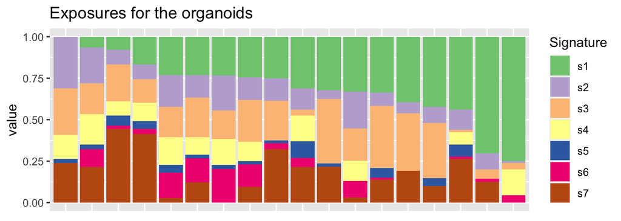

### 2.1.1 Data from Nat Gen paper

Only keep TCGA samples which are of good enough quality

### 2.1.2 Number of zeros in exposures

I have added the (previous) exposures from BriTROC and ICGC to this as well. This makes the organoids and the TCGA exposures sample, and leaves the other in the periphery of the PCA. I suspect this is due to the number of **zero exposures**, which are imputated using the robust analyses that I am using here:

```
## The percentage of zeros in every cohort is:
```

```
## $organoids
## [1] "13.492%"
##
## $britroc
## [1] "0%"
##
## $`OV-AU`
## [1] "0%"
##
## $`OV-US`
## [1] "0%"
##
## $TCGA
## [1] "0%"
##
## $britroc
## [1] "0%"
##
## $`OV-AU`
## [1] "0%"
##
## $`OV-US`
## [1] "0%"
##
## $`Updated TCGA`
## [1] "24.305%"
```

### 2.1.3 Reading in segments data

- The number of organoids is 18
- The number of TCGA samples in the previous (published) cohort was 374.
- The number of TCGA samples in the current (Ruben’s) cohort is 529.
- The number of TCGA samples found in the previous cohort but not in the current is 0.
- The number of TCGA samples found in the current cohort but not in the previous is 155.

```r
which_natgen = 1
```

In the new exposures S7 has relatively increased and S3 has relatively decreased.

# 3 PCA

For compositional data, in the book Analysing compositional data with R they say that PCA should be done on clr-transformed data. Zeroes are an issue if we use clr using all samples. The robust clr is implemented in the package compositions and deals with this problem by doing the geometric mean over only non-zero values, and setting the clr of a part which is zero to zero.

The plot done with (biplot(princomp(acomp(x)))) is the same as plotting princomp(as(clr(x), ‘matrix’))

## 3.1 Projecting

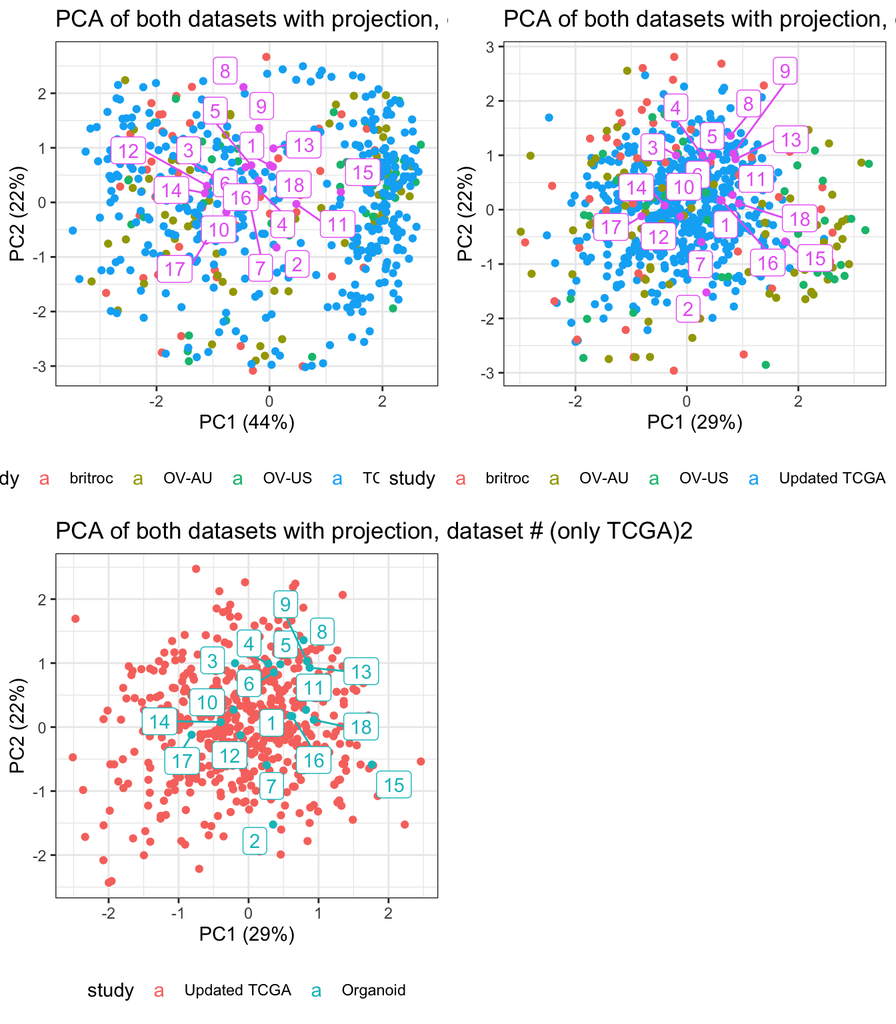

### 3.1.1 What is different in these ‘underrepresented’ samples?

Conclusion: it seems as though it’s signature 3, the relative abundance of which is never high in organoid samples.

I am comparing

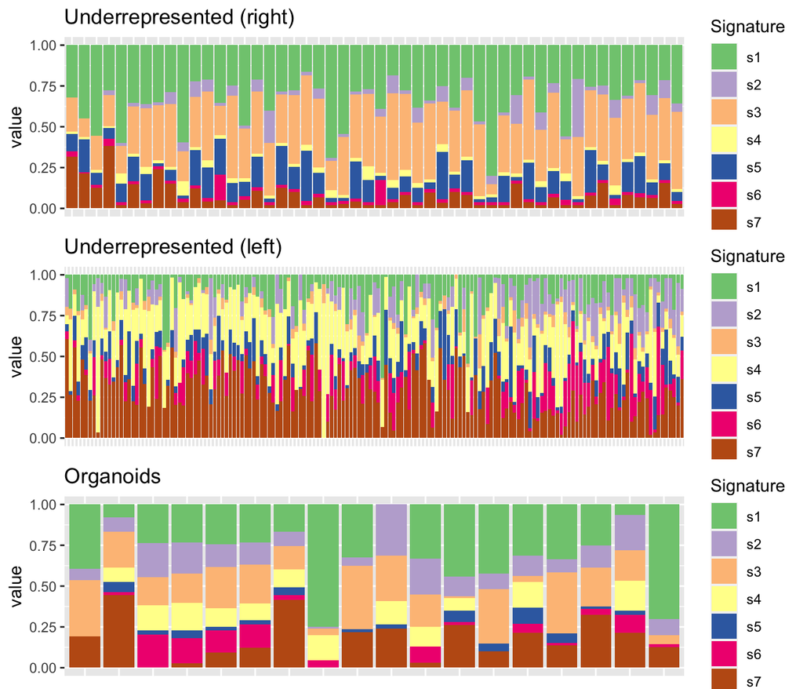

```
## Creating plot... it might take some time if the data are large. Number of samples: 50
## Creating plot... it might take some time if the data are large. Number of samples: 159
## Creating plot... it might take some time if the data are large. Number of samples: 18
```

### 3.1.2 Loadings

Looking at the loadings. In particular, looking for components in the first and second PC

Respectively, using the first and the second batch of signatures.

[figure not shown]

[figure not shown]

Signatures 3 and 6 seem to be quite important for the underrepresented groups

## 3.2 Creating a new PCA

We have two sets of exposures for the TCGA:

- the ones from the paper
- the ones which are, theoretically, better defined (there was a small bug in the code, and we are not taking into account normal segments, I believe)

The results are basically the same

The colour of the labels shows whether there is any zero exposure in the vector of exposures of the sample.

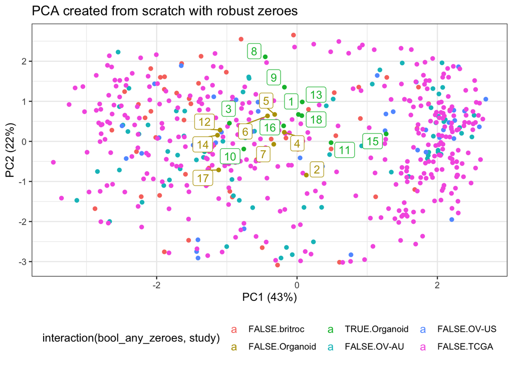

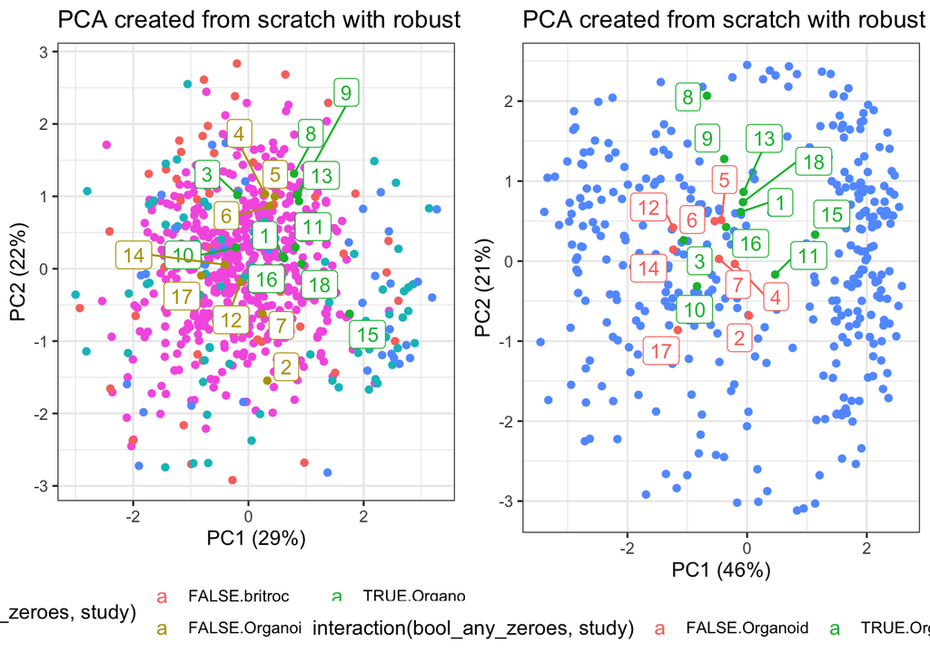

What we can see is that the exposures from the new exposures are much more distributed everywhere in the first two components of the PCA, but in fact given that the variance explained by the principle components in the previous dataset is much larger, it migth be that they are in fact explaining the same.

Pseudocounts analysis (not shown)

The lower the pseudocount, the more the organoid samples are left out of the PCA of all other samples.

That is because there is quite a good representation of signature landscapes in the NatGen samples, so

that anything with more non-zero exposures is likely to be represented

```r
which_natgen = 1
```

Exposures from Nat Gen don’t have zeroes; for organoids many do.

# 4 Dendrograms

## 4.1 Dendrogram based on the signatures

```
##  removed due to infinite values
```

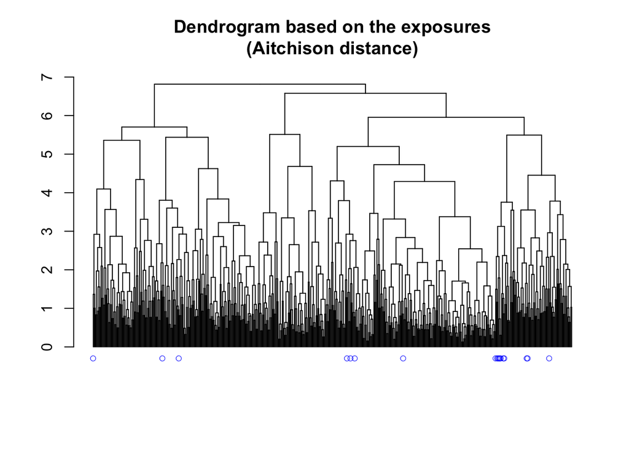

```
##  removed due to infinite values
```

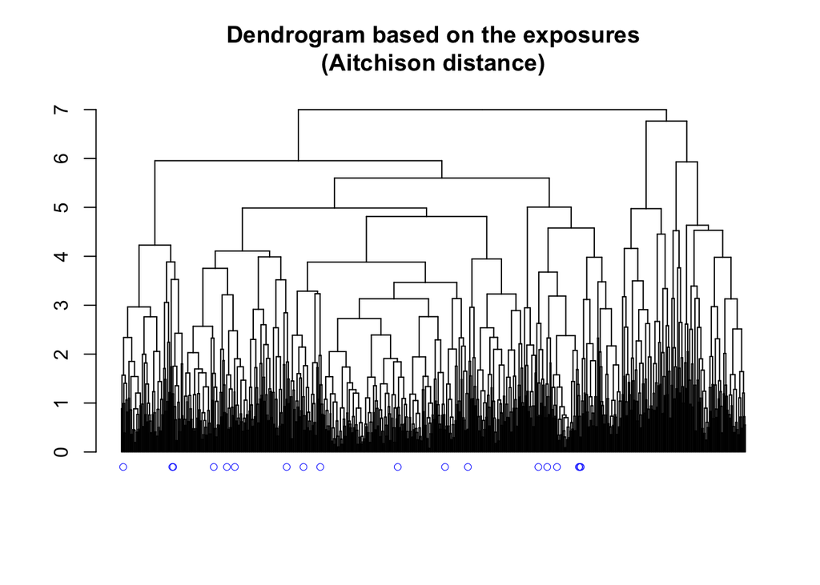

# 5 Analysis of CN profiles

additional genomic data comparing the tumours to the organoids in terms of ploidy, number of rearrangements and any other things that you think could be relevant

The number of segments can be taken eitehr from segsize (first column) or from copynumber (last column). This is just for PCAWG and TCGA! Not for BriTROC. Any idea why this is the case?

** Note I am plotting this as the log!**

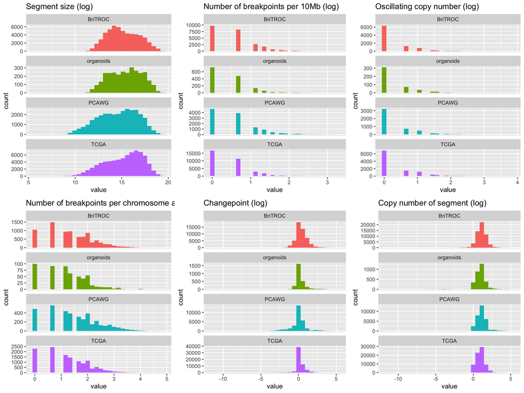

## 5.1 Number of segments; Poisson and NegBin GLM

TL;DR with a negative binomial model, which is much more appropriate in this setting than a Poisson, there is no difference in the distributions of organoids and non-organodis when it comes to **number of segments**.

```
## Analysis of Deviance Table
##
## Model 1: length ~ 1
## Model 2: length ~ bool
##   Resid. Df Resid. Dev Df Deviance  Pr(>Chi)
## 1      1104      80497
## 2      1103      80402  1   94.384 < 2.2e-16 ***
## ---
## Signif. codes:  0 '***' 0.001 '**' 0.01 '*' 0.05 '.' 0.1 ' ' 1
```

```
## Likelihood ratio tests of Negative Binomial Models
##
## Response: length
##   Model    theta Resid. df    2 x log-lik.   Test    df LR stat.  Pr(Chi)
## 1     1 2.971698      1104       -13390.84
## 2  bool 2.975302      1103       -13389.39 1 vs 2     1 1.458211 0.227215
```

Unfortunately the scaling factor has to do with the width of the bins in the histogram.

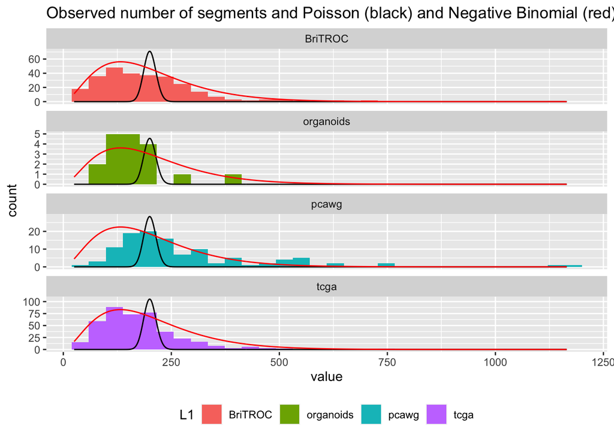

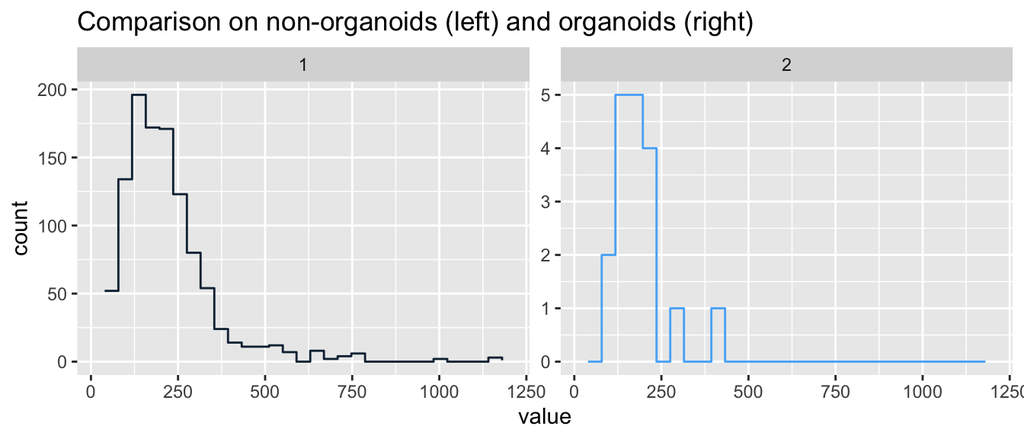

This seems to suggest that they do belong to different poissons.

## 5.2 Ploidy

To get the ploidy, I just have to compute the weighted average of the copy number segments (this is computed from the absolute copy number profiles objects, since they specify, for each segment, its length and its ploidy).

Use getSegTable to get the segments from this Biobase file

```
## Check that there are no sex chromosomes included anywhere
```

```
## [1] TRUE TRUE TRUE TRUE TRUE
```

Ploidy is not normally distributed and it’s right-skewed. Moreover, the distribution is bimodal: I guess there are genomes in which there is a clear amplification and genomes which are more or less normal, so centered around 2.

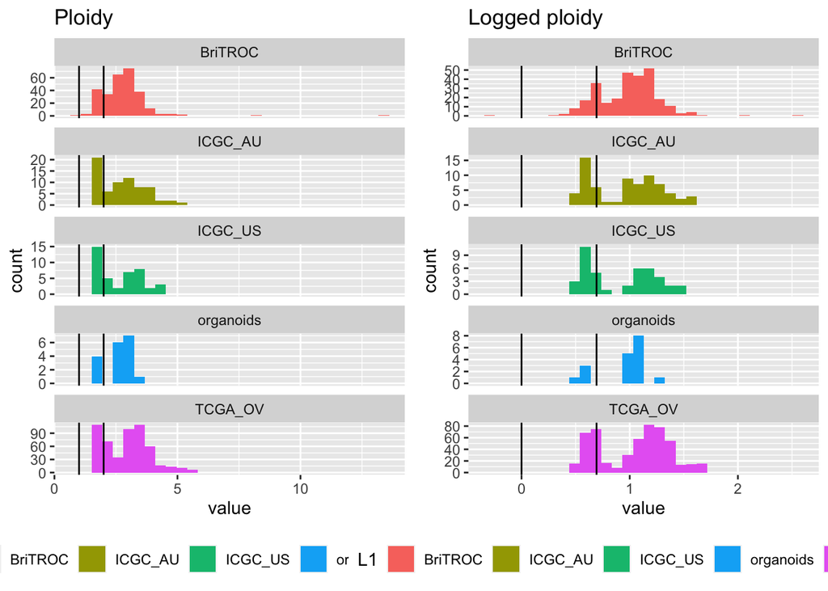

I am also using a robust linear regression, but I don’t think this is suitable either.

```r
t.test(log(ploidy_organoids), log(ploidy_BriTROC))
```

```
##
##  Welch Two Sample t-test
##
## data:  log(ploidy_organoids) and log(ploidy_BriTROC)
## t = -0.90962, df = 20.948, p-value = 0.3734
## alternative hypothesis: true difference in means is not equal to 0
## 95 percent confidence interval:
##  -0.16268846  0.06368736
## sample estimates:
## mean of x mean of y
## 0.9401143 0.9896149
```

```r
MASS::rlm(ploidy~group,
         data=cbind.data.frame(ploidy=c(ploidy_organoids, ploidy_BriTROC), group=c(rep(1,length(ploidy_organoids)), rep(2, length(ploidy_BriTROC)))))
```

```
## Call:
## rlm(formula = ploidy ~ group, data = cbind.data.frame(ploidy = c(ploidy_organoids,
##     ploidy_BriTROC), group = c(rep(1, length(ploidy_organoids)),
##     rep(2, length(ploidy_BriTROC)))))
## Converged in 5 iterations
##
## Coefficients:
## (Intercept)       group
##   2.4791559   0.1280964
##
## Degrees of freedom: 298 total; 296 residual
## Scale estimate: 0.675
```

```r
names(ploidy_organoids) = colnames(organoids_absolute_copynumber)
cbind(Ploidy=sort(ploidy_organoids))
```

```
##             Ploidy
## 54059org  1.715556
## 32077org  1.719599
## 119025org 1.752252
## 151761org 1.865682
## 23868org  2.595914
## 119127org 2.617572
## 119148org 2.639571
## 118947org 2.706511
## 54276org  2.753563
## 54288org  2.805061
## 151773org 2.818707
## 119058org 2.825767
## 50495org  2.864533
## 32070org  2.884280
## 119178org 2.886007
## 118976org 2.921865
## 54327org  3.042383
## 151723org 3.659920
```